# Perspectives on Computational Modeling: Problem Set #8

Xingyun Wu

2017/3/5

## Part 1: Sexy Joe Biden

### 1.

The `biden` data is splitted as required.

### 2.

`biden` is the response variable, and all the other variables are predictors. Contents below show the results and plot of the tree with default setting. According to the summary table, only two predictors are actually used in tree construction: `dem` and `rep`. According to the tree plot, we get the following results: (1) When the observation is a Democrat (`dem` = 1, indicating ‘True’), the average biden thermometer would be 74.51. (2) When the observation is not a Democrat (`dem` = 0, indicating ‘False’): - when the observation is a Republican (`rep` = 1, indicating ‘True’), the average biden thermometer would be 43.23; - when the observation is not a Republican (`rea` = 0, indicating ‘False’), the average biden thermometer would be 57.60.

```
##
## Regression tree:
## tree(formula = biden ~ female + age + dem + rep + educ, data = biden_split$train)
## Variables actually used in tree construction:
## [1] "dem" "rep"
## Number of terminal nodes:  3
## Residual mean deviance:  400 = 505000 / 1260
## Distribution of residuals:
##    Min. 1st Qu.  Median    Mean 3rd Qu.    Max.
##   -74.5   -13.2     2.4     0.0    12.4    51.8
```

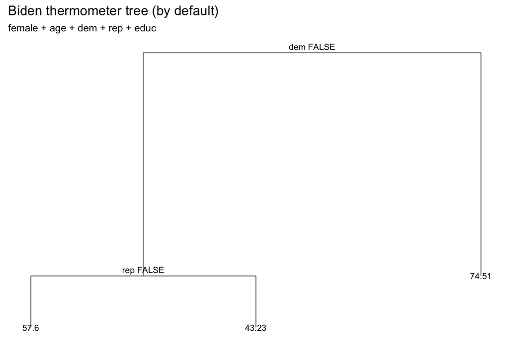

The test MSE is 406.4.

```
## [1] 406.4
```